# Growth Scenario - One Initial Infection Seeded, Non-Linear Contact Rate, Clustered Intensification

Cale Basaraba

### Introduction

This run of the simulator includes the implementation of a non-linear contact rate as well as clustered intensification of farms.

- Non-linear Contact rate ($\rho, \beta$): $(\beta I)/SIR^\rho = \beta_0$ , with $\beta_0$ = 0.8 at 2 chickens, $\beta_0$ = 0.004 at 1000 chickens.
- Clustered Intensification in Growth Scenario
- ~15 Chickens (Poisson distribution with 15 as mean)
- 100 Farms
- One initial seeded infection

#### Parameters

$\beta$ = 1.4456 – Contact rate implemented alongside $\rho$

$\gamma$ = 0.167 – Recovery rate

$\mu$ = 0.0 – Base mortality rate

$\alpha$ = 0.4 – Disease mortality rate

$\phi$ = 0.0 – Infectiousness of environmental virions

$\eta$ = 0.0 – Degradation of environmental virions

$\nu$ = 0.0 – Update rate of environmental virions

$\sigma$ = 0.0 – Virion shedding rate

$\omega$ = 0.03 – Inter-patch movement rate

$\rho$ = 0.8526 – Contact non-linearity parameter

$\lambda$ = 0.0 – External force of infection

$\tau$-crit = 0.0 – Critical surveillance time

$I$-crit = 0.0 – Threshold for reporting

$\pi$-report = 0.0 – Reporting probability

$\pi$-detect = 0.0 – Detection probability

### Initial Run

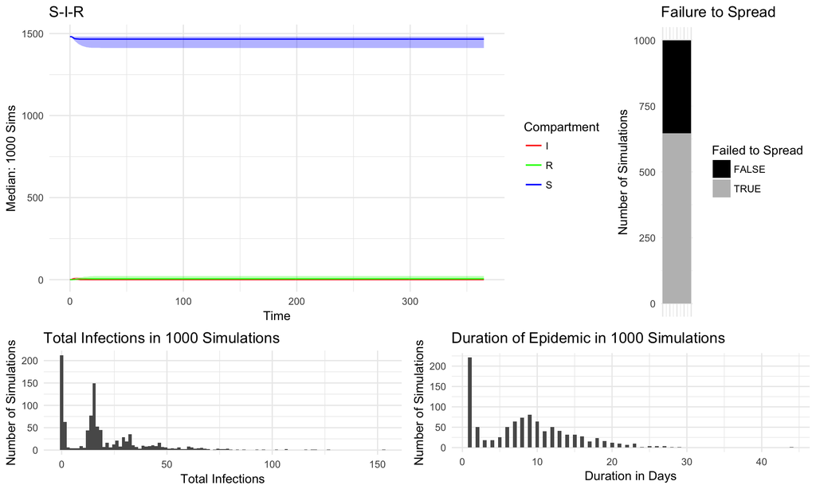

### Growth Run

Approximately 11% of the original farms grow to ten-times their original size (~15 to ~150), resulting in twice as many chickens in the entire network. For this experiment, the growing farms are chosen to be in the same neighborhood (adjacent in original network).

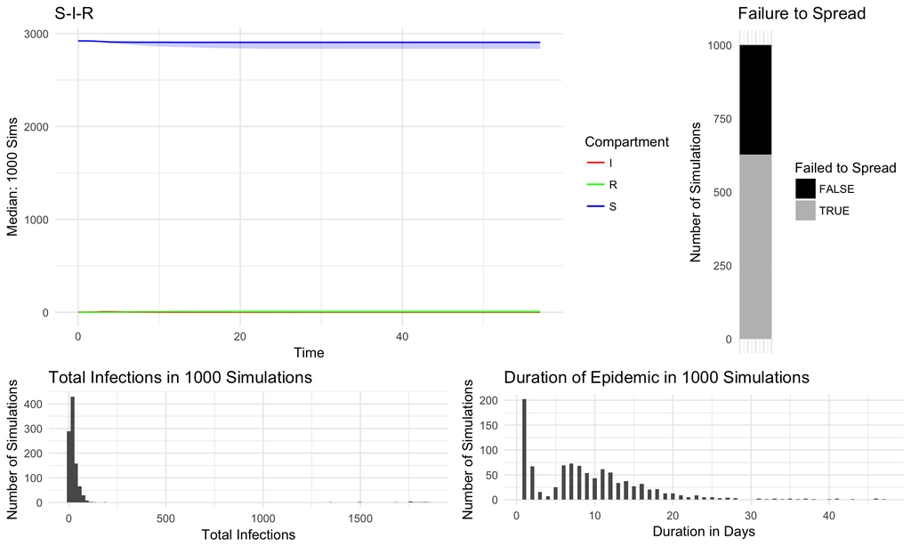